# Zadanie 1

Aleksander Jasiński

2025-03-12

### 1 Część I: Określenie kluczowych parametrów i założeń (zajęcia)

```r
set.seed(123)
alfa <- 0.05
s <- 1
m <- 0.5
n <- 10
```

Sprawdźmy **moc testu**, czyli prawdopodobieństwo, że odrzucimy hipoteze zerową, gdy jest ona fałszywa.

1. Losujemy 10 obserwacji z rozkładu N(m, s)

```r
los <- rnorm(n,m,s)
los
```

```
##  [1] -0.06047565  0.26982251  2.05870831  0.57050839  0.62928774  2.21506499
##  [7]  0.96091621 -0.76506123 -0.18685285  0.05433803
```

2. Przeprowadzamy test t dla średniej

```r
t.test(los)
```

```
##
##  One Sample t-test
##
## data:  los
## t = 1.9052, df = 9, p-value = 0.08915
## alternative hypothesis: true mean is not equal to 0
## 95 percent confidence interval:
##  -0.1076704  1.2569217
## sample estimates:
## mean of x
## 0.5746256
```

Wartość `p-value` jest większa od przyjętego poziomu istotności, a więc nie ma podstaw do odrzucenia hipotezy zerowej. Przejdźmy dalej.

3. Powtarzam krok 1-2 1000 razy

```r
N <- 1000
los <- replicate(N, rnorm(n,m,s))
odrzucone_H0 <- 0

for (i in 1:N) {
  test <- t.test(los[, i])
  if (test$p.value < alfa) {
    odrzucone_H0 <- odrzucone_H0 + 1
  }
}

wynik_norm <- odrzucone_H0/N
wynik_norm
```

```
## [1] 0.299
```

W przybliżona wartość mocu testu wynosi **30%**. Czyli w 30% przypadków test poprawnie odrzuci hipotezę zerową, gdy jest ona fałszywa.

4. Narysujmy wykres krzywej mocy dla zmieniających się wartości średniej rzeczywistej `mu`

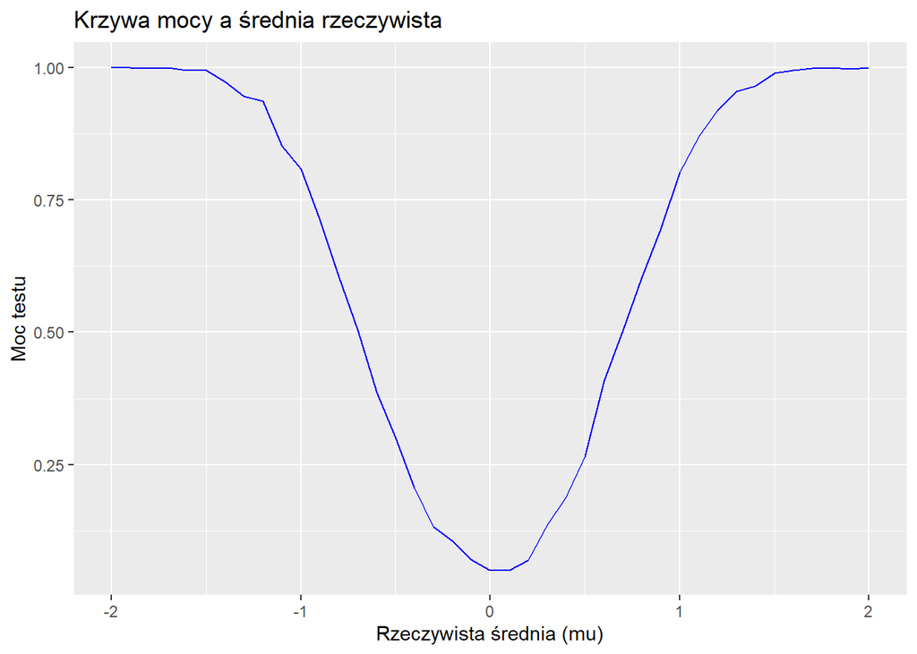

```r
mu <- seq(-2,2,by=0.1)
wynik_moc<-numeric(length(mu))
for(l in 1:length(mu))
{
  odrzucone_H0 <- 0
  nieodrzucone_H0 <- 0
  srednia<-mu[l]
  for (i in 1:N) {
  los <- rnorm(n,srednia,s)
  test <- t.test(los)
  if (test$p.value < alfa) {
    odrzucone_H0 <- odrzucone_H0 + 1
  } else {
    nieodrzucone_H0 <- nieodrzucone_H0 + 1
  }
  }
  wynik_moc[l]<-odrzucone_H0/N
}
wykres1 <- data.frame(mu, wynik_moc)
p1 <- ggplot(wykres1, aes(mu, wynik_moc))+
  geom_line(color="blue")+
  xlab("Rzeczywista średnia (mu)")+
  ylab("Moc testu")+
  ggtitle("Krzywa mocy a średnia rzeczywista")
p1
```

### 2 Część II: Sprawdzam zmienność wyniki testu w zależności od alfy

Przypisuje do zmiennj `alfy` poszczególne wartości poziomu istotności, a następnie sprawdzam *moc testu* w zależności od jej wartości. Dodatkowo “resetuje” wartość `odrzucone_H0` oraz `nieodrzucone_H0`.

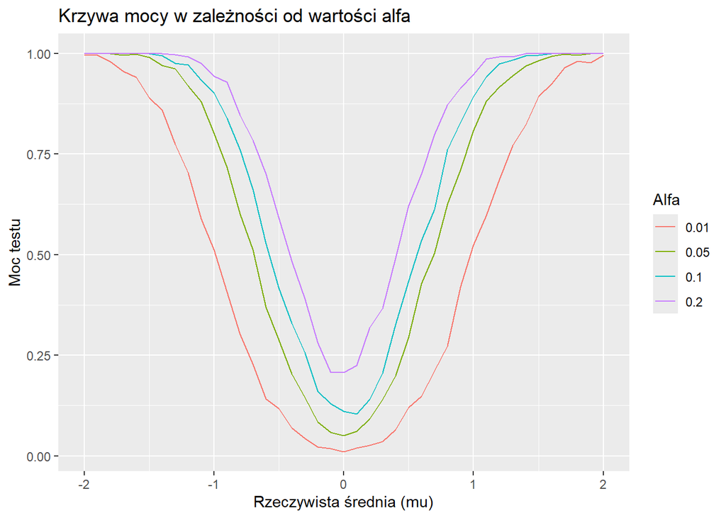

```r
af <- c( 0.01, 0.05, 0.1, 0.2)
wielkosc_mocy <- expand.grid(mu = mu, alfa = af)
wielkosc_mocy$moc <- NA

for (k in 1:length(af)) {
  for (l in 1:length(mu)) {
    odrzucone_H0 <- 0

    for (i in 1:N) {
      los <- rnorm(n, mu[l], s)
      test <- t.test(los)
      if (test$p.value < af[k]) {
        odrzucone_H0 <- odrzucone_H0 + 1
      }

    }

    wielkosc_mocy$moc[wielkosc_mocy$mu == mu[l] & wielkosc_mocy$alfa == af[k]] <- odrzucone_H0 / N

  }
}

p2 <- ggplot(wielkosc_mocy, aes(x = mu, y = moc, color = factor(alfa))) +
  geom_line() +
  xlab("Rzeczywista średnia (mu)") +
  ylab("Moc testu") +
  ggtitle("Krzywa mocy w zależności od wartości alfa") +
  scale_color_discrete(name = "Alfa")

p2
```

```r
moc_srednia <- aggregate(moc ~ alfa, data = wielkosc_mocy, mean)
moc_p1 <- ggplot(moc_srednia, aes(x = factor(alfa), y = moc)) +
  geom_bar(stat = "identity", fill = "steelblue", color = "black") +
  labs(title = "Średnia moc testu a alfa",
       x = "Poziom istotności (alfa)",
       y = "Moc testu") +
  theme_minimal()
```

**Wraz ze wzrostem poziomu istotności proporcja próbek, w których odrzucamy hipotezę zerową do próbek, w których jej nie odrzucamy rośnie, czyli:**

*Im niższa wartość alfa (np. 0.01), tym moc testu jest niższa, co oznacza większe prawdopodobieństwo popełnienia błędu II rodzaju*

### 3 Część III: Wpływ liczebności próby

Przypisuje do zmiennej `licznosc` poszczególne wielkości próby, a następnie sprawdzam *moc testu* w zależności od wielkości.Dodatkowo “resetuje” wartość `odrzucone_H0` oraz `nieodrzucone_H0`.

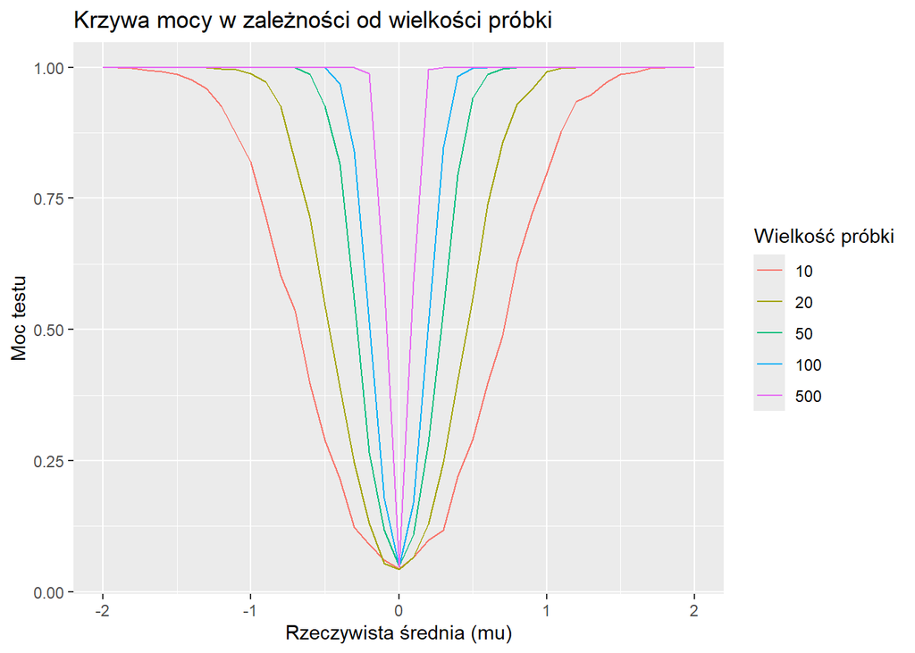

```r
licznosc <- c(10, 20, 50, 100,500)
wielkosc_mocy2 <- expand.grid(mu = mu, n = licznosc)
wielkosc_mocy2$moc <- NA

for (k in 1:length(licznosc)) {
  for (l in 1:length(mu)) {
    odrzucone_H0 <- 0

    for (i in 1:N) {
      los <- rnorm(licznosc[k], mu[l], s)
      test <- t.test(los)
      if (test$p.value < alfa) {
        odrzucone_H0 <- odrzucone_H0 + 1
      }
    }

    wielkosc_mocy2$moc[wielkosc_mocy2$mu == mu[l] & wielkosc_mocy2$n == licznosc[k]] <- odrzucone_H0 / N
  }
}
p3 <- ggplot(wielkosc_mocy2, aes(x = mu, y = moc, color = factor(n))) +
  geom_line() +
  xlab("Rzeczywista średnia (mu)") +
  ylab("Moc testu") +
  ggtitle("Krzywa mocy w zależności od wielkości próbki") +
  scale_color_discrete(name = "Wielkość próbki")

p3
```

```r
moc_licznosc <- aggregate(moc ~ n, data = wielkosc_mocy2, mean)

moc_p2 <- ggplot(moc_licznosc, aes(x = factor(n), y = moc)) +
  geom_bar(stat = "identity", fill = "lightgreen", color = "black") +
  labs(title = "Średnia moc testu a licznosc",
       x = "Licznosc probki",
       y = "Moc testu") +
  theme_minimal()
```

- **W miarę zwiększania się liczności próbki (np. N=100, N=500), moc testu rośnie**, co oznacza, że test lepiej wykrywa rzeczywiste różnice w średnich.
- Krzywe dla większych próbek są bardziej strome i szybciej osiągają wartość bliską 1.
- Dla małych próbek dopiero duże wartości `mu` powodują wzrost mocy testu.

### 4 Część IV: wpływ rozkładu zmiennej.

1. Sprawdźmy wynik naszego testu dla rozkładu jednostajnego. Przymijmy założenia z **Część I**.

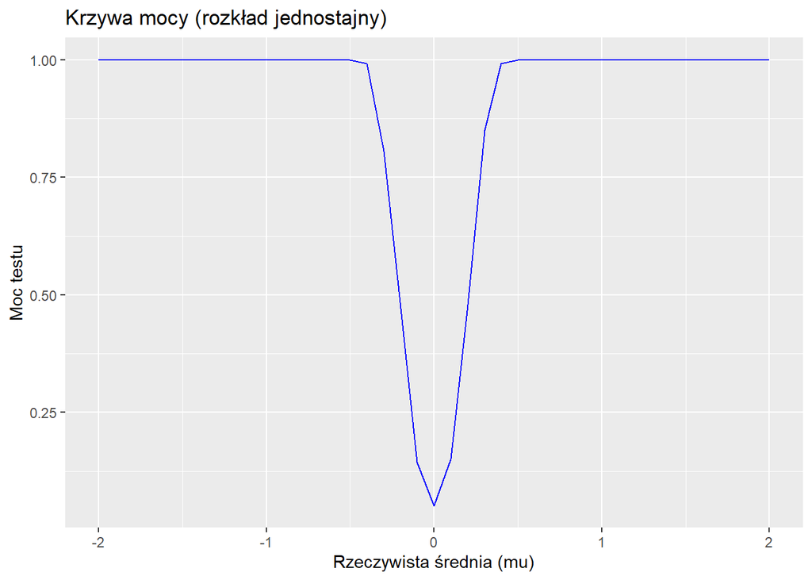

```r
min <- -0.5
max <- 0.5
N <- 1000
n <- 10
alfa <- 0.05

wielkosc_mocy <- data.frame(mu = mu, moc = NA)

for (l in 1:length(mu)) {
  odrzucone_H0 <- 0

  for (i in 1:N) {
    los <- runif(n, min + mu[l], max + mu[l])
    test <- t.test(los)
    if (test$p.value < alfa) {
      odrzucone_H0 <- odrzucone_H0 + 1
    }
  }

  wielkosc_mocy$moc[l] <- odrzucone_H0 / N
}


p4 <- ggplot(wielkosc_mocy, aes(x = mu, y = moc)) +
  geom_line(color = "blue") +
  xlab("Rzeczywista średnia (mu)") +
  ylab("Moc testu") +
  ggtitle("Krzywa mocy (rozkład jednostajny)")

p4
```

```r
N <- 1000
n <- 10
los <- replicate(N, rbinom(n, 10, 0.5))
odrzucone_H0 <- 0
for (i in 1:N) {
  test <- t.test(los[, i], mu=5)
  if (test$p.value < alfa) {
    odrzucone_H0 <- odrzucone_H0 + 1
  }
}
wynik_bimodal <- odrzucone_H0/N
wynik_bimodal
```

```
## [1] 0.047
```

Mamy niską wartość mocy testu, zbliżoną do 0.05.

Próbki mają średnią bardzo zbliżoną do wartości oczekiwanej z populacji.

3. Sprawdźmy rozkład `t-Studenta`

Rozkład t-studenta wraz ze wzrostem stopni swobody przypomina rozkład normalny.

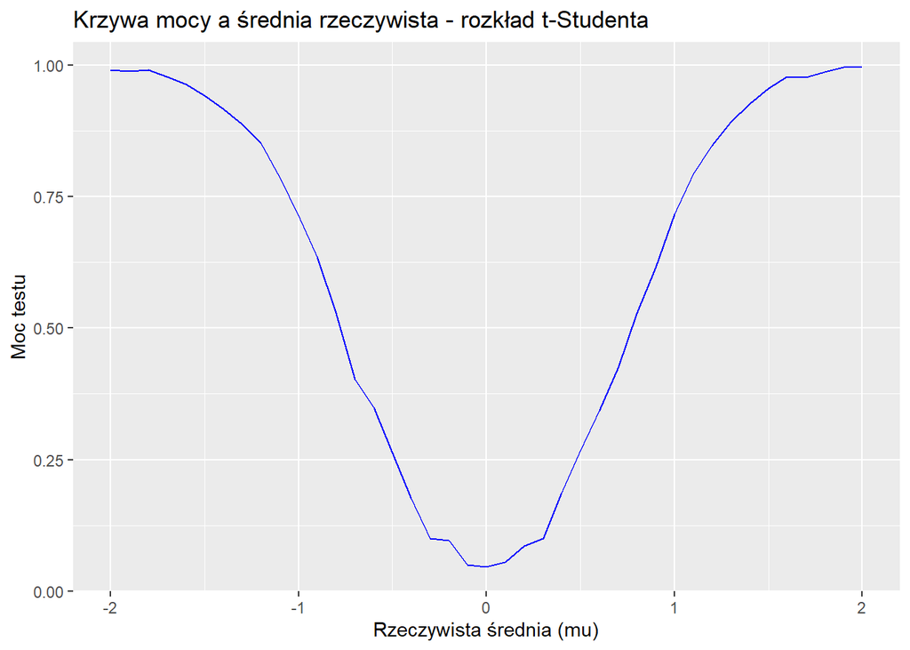

```r
wynik_moc <- numeric(length(mu))

for (l in 1:length(mu)) {
  odrzucone_H0 <- 0


  for (i in 1:N) {
    los <- rt(n, df=n-1) + mu[l]
    test <- t.test(los)

    if (test$p.value < alfa) {
      odrzucone_H0 <- odrzucone_H0 + 1
    }
  }

  wynik_moc[l] <- odrzucone_H0 / N
}

wykres1 <- data.frame(mu, wynik_moc)
p5 <- ggplot(wykres1, aes(mu, wynik_moc)) +
  geom_line(color="blue") +
  xlab("Rzeczywista średnia (mu)") +
  ylab("Moc testu") +
  ggtitle("Krzywa mocy a średnia rzeczywista - rozkład t-Studenta")

p5
```

Test t-Studenta jest stosunkowo odporny na niewielkie odstępstwa od normalności, dlatego *działa dobrze w tym przypadku*. Moc testu jest najwyższa dla wartości rzeczywistej średniej `mu`daleko od 0.

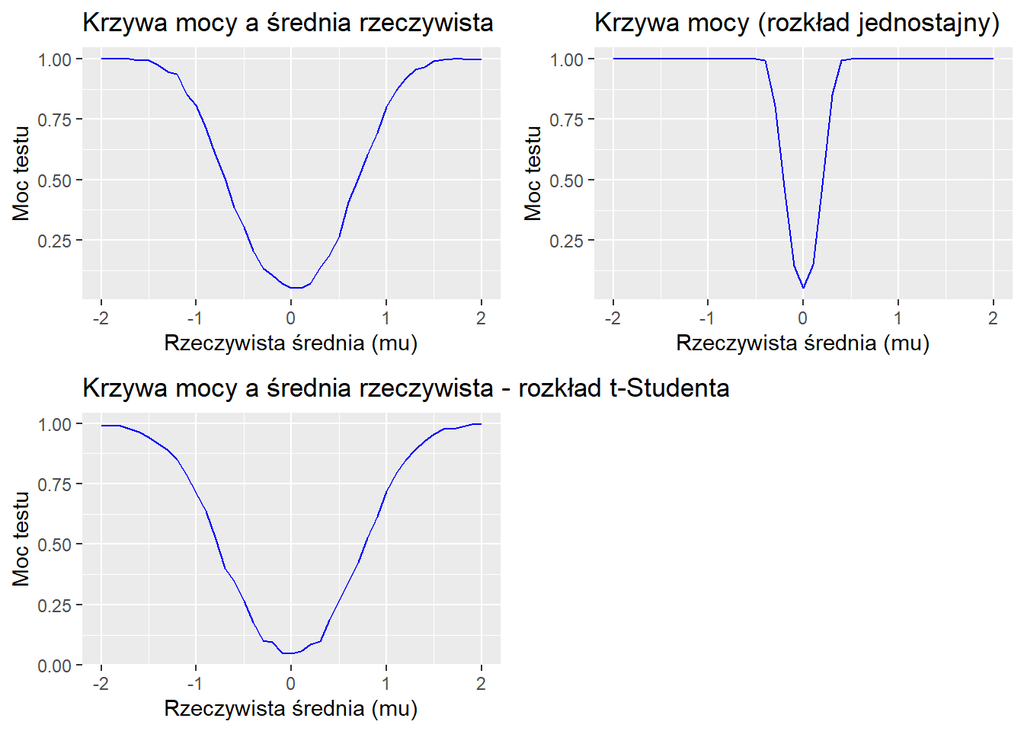

```r
grid.arrange( p1,p4, p5,ncol=2)
```

#### 4.1 Wnioski:

**Moc testu zależy nie tylko od wartości rzeczywistej średniej, ale także od kształtu rozkładu z którego pochodzą dane.**

### 5 Część V: wizualiacja wpływu poszczególnych czynników.

Spójrzmy jeszcze raz na poszczególne wykresy, które pojawiły się w trakcie mojej pracy.

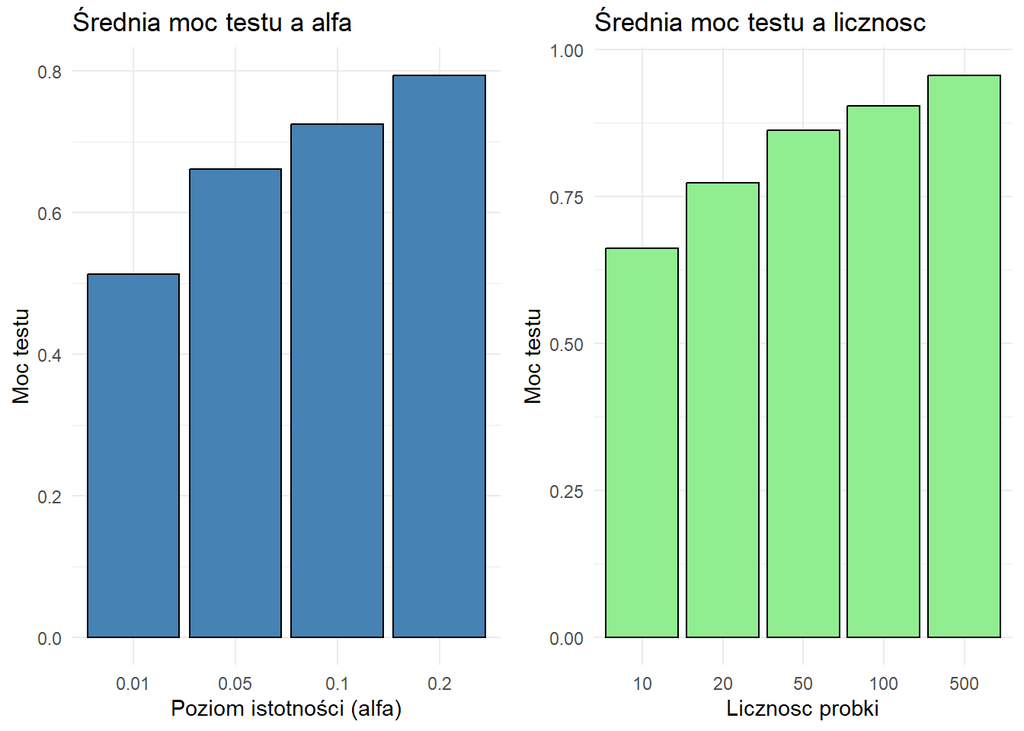

```r
grid.arrange(moc_p1,moc_p2,ncol=2)
```

- **Wyższa alfa** (kosztem większego ryzyka I rodzaju!!) oznacza większą skłonność do odrzucania hipotezy zerowej, co zwiększa prawdopodobieństwo wykrycia efektu, jeśli rzeczywiście istnieje.
- Przy **małych próbkach** test statystyczny może mieć niską moc, co oznacza większe prawdopodobieństwo popełnienia błędu II rodzaju

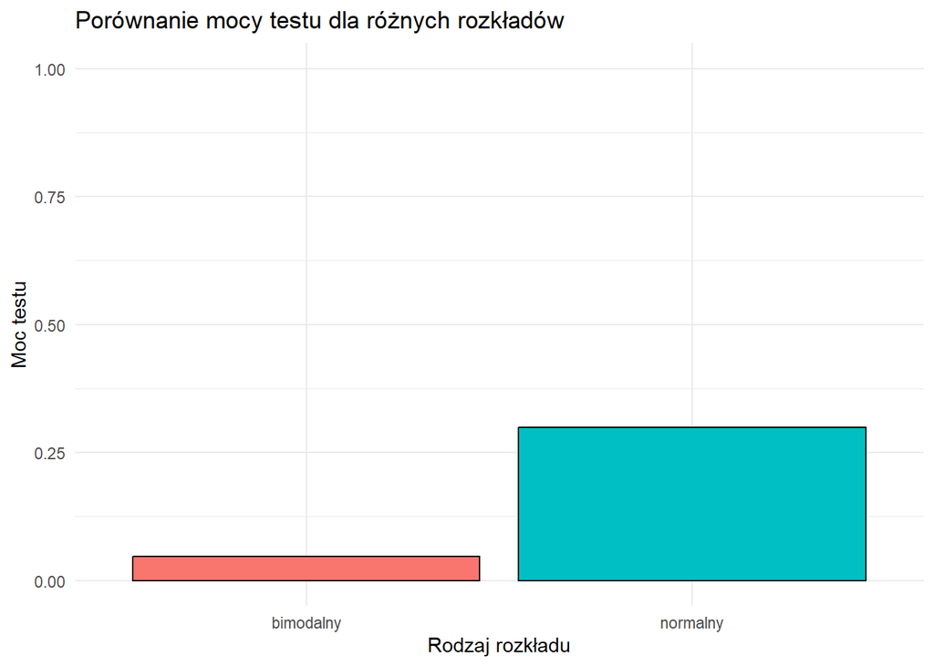

```r
norm_vs_bimod <- data.frame(rozklad=c("normalny","bimodalny"),moc=c(wynik_norm,wynik_bimodal))

ggplot(norm_vs_bimod, aes(x = rozklad, y = moc, fill = rozklad)) +
  geom_bar(stat = "identity", color = "black") +
  labs(title = "Porównanie mocy testu dla różnych rozkładów",
       x = "Rodzaj rozkładu",
       y = "Moc testu") +
  ylim(0,1)+
  theme_minimal() +
  theme(legend.position = "none")
```